# Introdução a Sistemas de Controle

Sistemas de Controle I — Controle Clássico

Prof. Dr. Raphael Teixeira

Universidade Federal do Pará

## O que é Controle Automático?

- **Controle** é o processo de fazer um sistema físico se comportar de uma maneira desejada
- Um **sistema de controle** manipula variáveis de entrada para que a saída siga um comportamento especificado
- Objetivo: fazer a saída $y(t)$ rastrear uma referência $r(t)$, mesmo na presença de **perturbações** e **incertezas** no modelo da planta

**Aplicações:**

- Controle de temperatura (fornos, ar-condicionado)
- Controle de velocidade (cruise control, motores)
- Controle de posição (robótica, CNC, antenas)
- Controle de nível (tanques, caldeiras)
- Reguladores de tensão
- Piloto automático (aeronaves, drones)

## Um Pouco de História

- **1788** — regulador centrífugo de Watt para máquinas a vapor (primeiro controle de realimentação amplamente usado na indústria)
- **1868** — James Clerk Maxwell analisa matematicamente a estabilidade do regulador de Watt (Maxwell 1868)
- **1927–1940** — Black, Nyquist e Bode (Bell Labs) desenvolvem a teoria de realimentação e resposta em frequência para amplificadores telefônicos
- **1942** — Ziegler e Nichols publicam regras práticas de sintonia de controladores PID (Ziegler and Nichols 1942)
- **1950–60** — consolidação do “controle clássico” (Laplace, função de transferência, LGR de Evans) e início do controle moderno (espaço de estados)

**Note**

O **controle clássico**, tema deste curso, opera no domínio da frequência complexa $s$ e é a base histórica e conceitual de toda a teoria de controle moderna.

## Componentes de um Sistema de Controle

| Componente | Descrição |
| --- | --- |
| **Planta** | Sistema físico a ser controlado |
| **Atuador** | Dispositivo que age sobre a planta |
| **Sensor** | Mede a saída real do sistema |
| **Controlador** | Calcula a ação de controle |
| **Referência** $r(t)$ | Valor desejado para a saída |
| **Erro** $e(t)$ | Diferença entre $r(t)$ e a saída medida |
| **Perturbação** $d(t)$ | Sinal indesejado que afeta a saída |

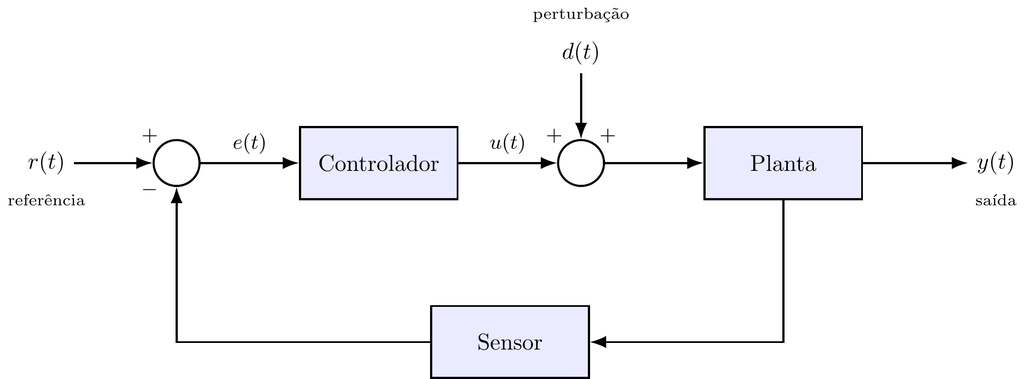

$$e(t) = r(t) - y(t)$$

## Malha Aberta

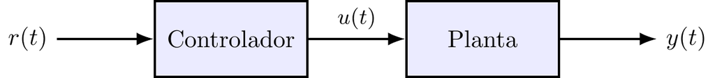

- A saída **não** é medida nem comparada com a referência
- O controlador aplica uma ação **pré-calculada**, independente do resultado real
- Simples e barato, **mas** sensível a perturbações e a variações da planta

**Tip**

**Exemplos:** torradeira (tempo fixo), máquina de lavar (ciclo fixo), semáforo de tempo fixo.

## Malha Fechada (Realimentação Negativa)

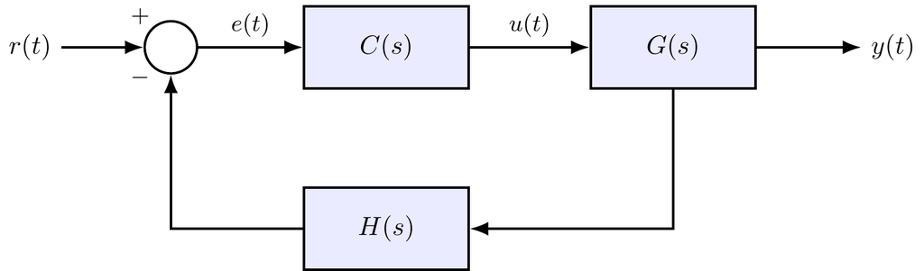

- A saída é **medida** (pelo sensor $H(s)$) e comparada com a referência
- O controlador atua sobre o **erro** $e(t) = r(t) - y(t)$
- Robusto a perturbações e a variações paramétricas da planta; pode corrigir erros automaticamente

**Tip**

**Exemplos:** termostato, piloto automático, controle de velocidade de cruzeiro.

## Malha Aberta vs. Malha Fechada

|  | Malha Aberta | Malha Fechada |
| --- | --- | --- |
| **Mede a saída?** | Não | Sim |
| **Custo/complexidade** | Baixo | Maior (sensor + comparação) |
| **Sensibilidade a perturbações** | Alta | Reduzida |
| **Sensibilidade a variações da planta** | Alta | Reduzida |
| **Estabilidade** | Sempre que a planta for estável | Pode instabilizar se mal projetada |
| **Precisão em regime permanente** | Depende só da planta | Pode ser melhorada pelo controlador |

**Important**

A realimentação **não é grátis**: ela introduz o risco de instabilidade e exige um sensor confiável. Grande parte deste curso trata de como projetar controladores que explorem os benefícios da realimentação com segurança.

## Sinais e Variáveis do Sistema

Em um sistema de controle em malha fechada, identificamos:

- $r(t)$ — referência ou *set point*: valor desejado da saída
- $y(t)$ — saída controlada: variável que se deseja regular
- $e(t) = r(t) - y(t)$ — sinal de erro atuante
- $u(t)$ — sinal de controle: saída do controlador, entrada da planta
- $d(t)$ — perturbação: sinal indesejado que afeta a saída
- $n(t)$ — ruído de medição (frequentemente desprezado em uma primeira análise)

**Note**

O controlador $C(s)$ é projetado para que $y(t) \to r(t)$ **mesmo na presença** de $d(t)$ e de incertezas em $G(s)$.

## Modelagem Matemática — Motivação

Para **projetar** um controlador precisamos de um **modelo matemático** da planta que relacione a entrada $u(t)$ com a saída $y(t)$.

**Equação Diferencial Ordinária (EDO)**

Sistema linear invariante no tempo (LIT) de ordem $n$:

$$a_n \frac{d^n y}{dt^n} + \cdots + a_1 \frac{dy}{dt} + a_0 y = b_m \frac{d^m u}{dt^m} + \cdots + b_0 u$$

- Coeficientes $a_i, b_i$ constantes reais
- Difícil de manipular algebricamente e de generalizar para blocos interligados

**A solução: Transformada de Laplace**

- Converte EDOs em equações **algébricas** em $s$
- Introduz a **função de transferência** $G(s) = Y(s)/U(s)$
- Permite representar e **combinar** subsistemas por **diagramas de blocos**

Esse é o tema da próxima aula.

## Objetivos de um Projeto de Controle

Um controlador é projetado para atender a especificações de três naturezas:

1. **Estabilidade** — requisito mínimo: o sistema em malha fechada não pode divergir
2. **Resposta transitória** — velocidade e qualidade da resposta (tempo de subida, sobressinal, tempo de acomodação)
3. **Erro de regime permanente** — precisão da saída após o transitório desaparecer

**Important**

Esses três objetivos frequentemente **competem** entre si (ex.: reduzir o erro aumentando o ganho tende a piorar o sobressinal e pode até instabilizar o sistema). Todo o curso constrói ferramentas para navegar esse compromisso.

## Roteiro do Curso

| Bloco | Conteúdo |
| --- | --- |
| Modelagem | Laplace, função de transferência, diagrama de blocos |
| Resposta transitória | Sistemas de 1ª e 2ª ordem, polos dominantes |
| Regime permanente | Erro de regime permanente, tipo de sistema |
| Estabilidade e projeto no domínio de $s$ | Routh-Hurwitz, Lugar Geométrico das Raízes (LGR) |
| Domínio da frequência | Diagramas de Bode, margens de ganho e fase |
| Controladores | Ação P, PI, PD, PID e sintonia |

## Exercícios

1. Cite três sistemas de controle do seu cotidiano e classifique cada um como malha aberta ou malha fechada, justificando.
2. Para um sistema de controle de temperatura de um chuveiro elétrico com termostato, identifique $r(t)$, $y(t)$, $u(t)$, $e(t)$ e uma possível perturbação $d(t)$.
3. Explique, em suas palavras, por que a realimentação negativa reduz a sensibilidade do sistema a variações na planta, mas pode introduzir risco de instabilidade.
4. Pesquise e descreva resumidamente o funcionamento do regulador centrífugo de Watt (1788) e sua importância histórica para a teoria de controle.

## Referências

Maxwell, James Clerk. 1868. “On Governors.” *Proceedings of the Royal Society of London* 16: 270–83.

Ziegler, John G., and Nathaniel B. Nichols. 1942. “Optimum Settings for Automatic Controllers.” *Transactions of the ASME* 64: 759–68.